# USMR Lecture 2

The groundwork

Milan Valášek

Click for slides

## Introductory Stuff

### Arrest this man, he talks in maths

- There will be numbers, there will be maths
- Maths (and logic) is the language of computers, statistics, science, and – it seems – the universe
- We will focus on developing a conceptual understanding and intuition
- We won’t discuss anything that is beyond your capability to understand
- It won’t be a walk in the park though so do put in the hours

### If you find yourself struggling

- Go back to where you last felt on top of things and take it from there
- **Come** talk to us
- **Ask** questions during the lectures
- Make use of the discussion forum on LEARN
- Take a deep breath, go for a walk, **you’ll be fine**!

### Before we start

- All clear regarding research questions/design and measurement?

### Today

- Logic, probability
  - Probability theory is the basis for all of statistics
  - Sits on a foundation of logic (and set theory)
  - Not the focus of this course but we need to talk about these topics a little
- Sampling & independence
- Variables
  - Descriptive statistics

## That’s logic, innit!

### Logic

- Informally, a discipline concerned with truth value of statements, relationships between objects, and inference based on them
- There are several systems of logic but we will only discuss [Boolean](https://en.wikipedia.org/wiki/Boolean_algebra) logic, in which a statement can be exclusively either `TRUE` (1) or `FALSE` (0)
- The basis of all maths and computing
- If you want to be able to code, you need to understand at least the basics
- *Note.* The following is a **strictly informal** treatment of logic. Instead of using formal notation, I will use the `R` notation

### Logic: **Truth value**

- Statement is a meaningful utterance about objects in the world and their relationships.
  - *e.g.,* *“Today is Wednesday.”* or *“Two is equal to five.”*
- Based on the nature of the relationships and the premises, a statement can either be `TRUE` (1) or `FALSE` (0)
- Premises don’t have to be *“true”* in the sense of corresponding to our experience of reality. We can assess the truth value of a statement even if it’s based on outlandish premises
1. *All rivers are laughter*
2. *All laughter takes a chance*  
   Therefore
3. *All rivers take a chance*

```r
## R-ish for "equals" or "is" is ==, not = !
weekdays(Sys.Date()) == "Wednesday"
[1] TRUE

2 == 5
[1] FALSE

## object orange has the value "apple" (premise)
orange <- "apple"
orange == "apple"
[1] TRUE
```

### Logic: **Boolean operators**

- Logical operators express relationships between objects (equality, `==`, is an example)
- There are lots of them but we will focus on four *Boolean operators*:
  - NOT (`!`)
  - AND (`&`)
  - OR (`|`)
  - exclusive OR, XOR (the `xor()` function in `R`)
- They are quite intuitive except for the OR/XOR distinction
- A statement linking two objects statements with OR is `TRUE` if **either** of the partial statements is `TRUE` **or both of them** are `TRUE`
- XOR returns `TRUE` **if and only if one of the statements** is `TRUE`

### Logic in `R`

- *Note.* `%in%` is a membership operator in `R` – `a %in% A` means “element `a` is in the object `A`”; Its result is `TRUE`/`FLASE`

```r
A <- 1:5 # A contains numbers from 1 to 5
B <- c(-1, 3, 5, 7) # B contains numbers -1, 3, 5, and 7

1 %in% A
[1] TRUE

1 %in% B
[1] FALSE
```

### Logic: **NOT (`!`)**

- The simplest operator
- Negates the subsequent statement, *i.e.,* turns `TRUE` to `FALSE` and *vice versa*
- if `A == B` is `FALSE`, `!(A == B)` or `A != B` will be `TRUE`

```r
a <- TRUE
!a
[1] FALSE

!(1 %in% A)
[1] FALSE
```

### Logic: **AND (`&`)**

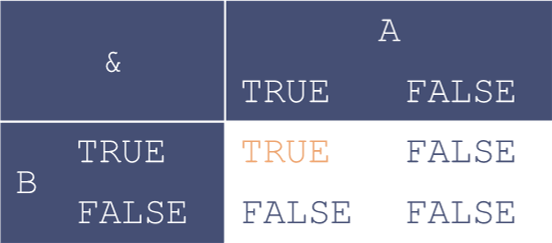

Truth table of A AND B

```r
1 %in% A & 5 %in% B # 1 is in A AND 5 is in B
[1] TRUE
```

`!(A & B)` is equivalent to `xor(A, B) | (!A & !B)`

### Logic: **OR (`|`)**

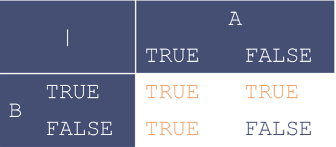

Truth table of A OR B

```r
-30 %in% A | 5 %in% B # first FALSE, second TRUE
[1] TRUE
```

`!(A | B)` is equivalent to `(!A & !B)`

### Logic: **XOR (`xor()`)**

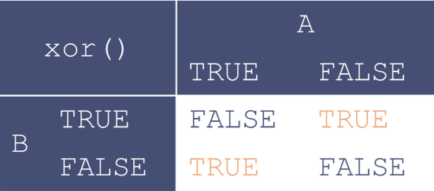

Truth table of A XOR B

```r
xor(5 %in% A, -1 %in% B) # both TRUE
[1] FALSE
```

`!xor(A, B)` is equivalent to `(A & B) | (!A & !B)`

## Probability matters (p < .001)

### Probability

- System of attributing chance to events
- Based on a foundation of logic
- Informs all of statistics
- Main approaches: [frequentist](https://en.wikipedia.org/wiki/Frequentist_probability) and [Bayesian](https://en.wikipedia.org/wiki/Bayesian_probability)
- We focus on the frequentist approach but be aware that Bayesian statistics has been gaining a lot of traction in recent years

### It’s a tricky business

- Unlike things we’ve talked about, probability is not intuitive
- We didn’t evolve to solve probabilistic problems analytically but to adopt heuristics
- The whole field started as a result of this counter-intuitive nature
  - One Antoine Gombaud, Chevalier de Méré noticed that when he bet on rolling **at least 1 double-six in 24 rolls of two dice**, he lost more often than when he bet on rolling **at least 1 six in 4 rolls of a single die** and was puzzled by it and challenged mathematicians to explain why
  - Blaise Pascal and Pierre de Fermat took up the challenge and, between themselves, laid the groundwork of modern probability theory

### Two goats and a car

- Another great historical example is the [Monty Hall problem](https://en.wikipedia.org/wiki/Monty_Hall_problem)
- Originally posed and solved in the 70s ([Selvin, 1975](https://www.jstor.org/stable/2683689)), it gained prominence in 1990, when it appeared in [Marilyn vos Savant](https://en.wikipedia.org/wiki/Marilyn_vos_Savant)’s column in Parade magazine
- The correct answer provoked a massive outcry ([transcript](http://marilynvossavant.com/game-show-problem/))

#### The problem

> Suppose you’re on a game show, and you’re given the choice of three doors. Behind one door is a car, behind the others, goats. You pick a door, say #1, and the host, who knows what’s behind the doors, opens another door, say #3, which has a goat. He says to you, *“Do you want to pick door #2?”* Is it to your advantage to switch your choice of doors?

### Definition

If there are $a$ ways in which $X$ can occur and $b$ ways in which $X$ can fail to occur, then the probability of $X$ occurring is $P(X) = a/(a+b)$

### Jargon

- Let’s say we’re flipping a fair coin 10 times
- **Outcome** is the possible result; either heads (H) or tails (T)
- **Event** is a set of outcomes, *e.g.,* H H T H T T H H T H
- **Experiment** is the process generating simple events and producing outcome; flipping a coin
- **Sample space** is the set of all possible outcomes; all combinations of Hs and Ts of size 10

### Basic calculation

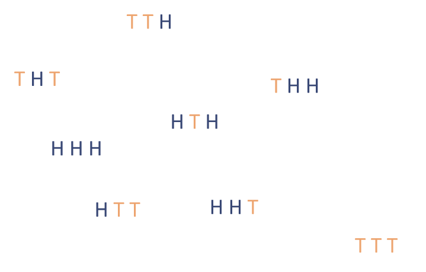

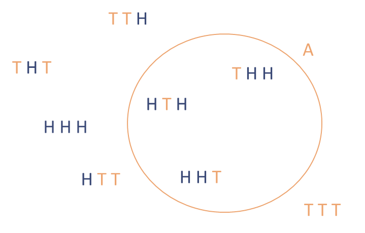

- Given definition above, since there are 3 ways we can get exactly one T and 5 ways we can get some other number of Ts, the probability of getting exactly one T if we flip a fair coin three times is $P(A) = 3 / (3 + 5)$

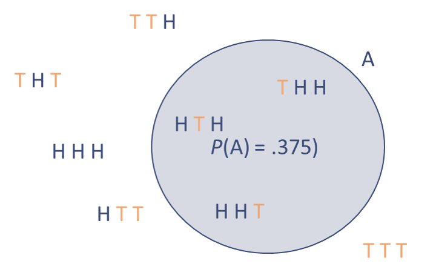

- Similarly, there is only one way of getting HHT (event $a$) when flipping a fair coin three times – and therefore seven ways this can fail to occur – so the probability of this happening is $P(a) = 1 / 8$

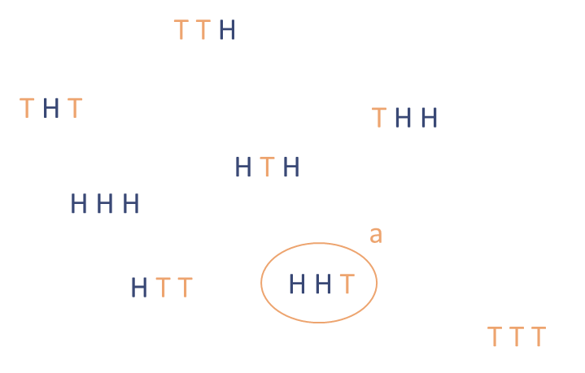

- OK, your turn, what is the probability of a subset of $A$ that does not include $a$?
- $P(A\ \&\ !a) = P(A) - P(a)$
- $P(A\ \&\ !a) = .375 - .125 = .250$

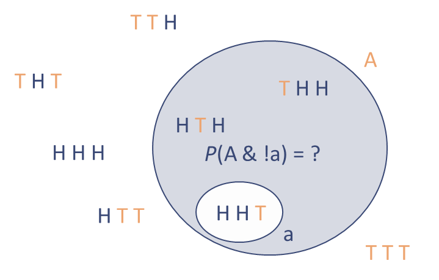

### Conditional probability

- Conditional probability $P(A|B)$ is the probability of $A$ occurring **given that $B$ occurred**
- Here, it’s the probability of getting exactly 1 T in 3 flips of a fair coin **given** H on the first flip
- *Note.* ‘|’ is conditional probability, not the ‘OR’ operation

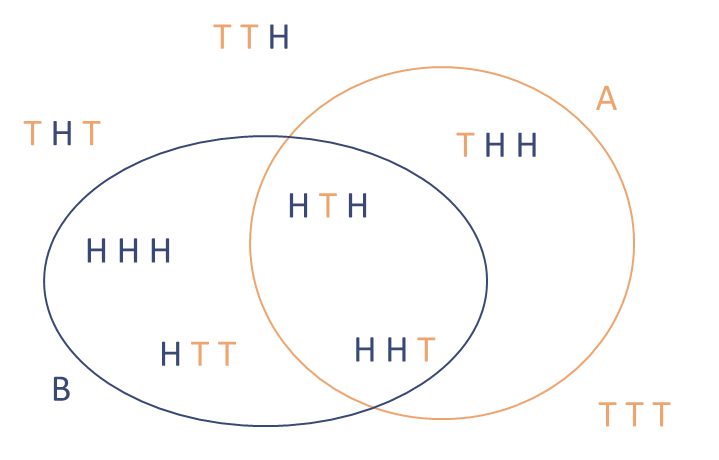

- To calculate $P(A|B)$ applying the [Bayes’ theorem](https://en.wikipedia.org/wiki/Bayes%27_theorem), we need to know the probability of $A$, the probability of $B$, and the probability of $B$ given $A$
- $P(A|B) = \frac{P(B\ \&\ A)}{P(B)} = \frac{P(B|A)\times P(A)}{P(B)} = \frac{2/3\times 3/8}{1/2}$

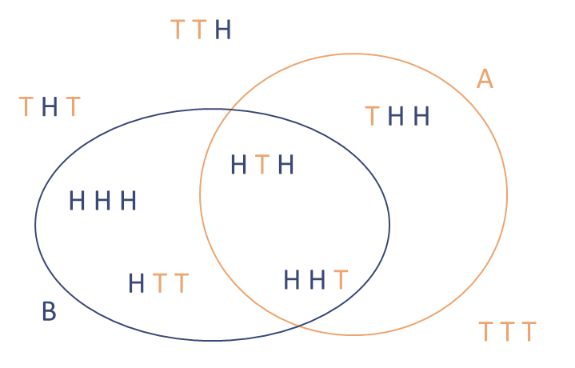

- To calculate $P(A|B)$ applying the [Bayes’ theorem](https://en.wikipedia.org/wiki/Bayes%27_theorem), we need to know the probability of $A$, the probability of $B$, and the probability of $B$ given $A$
- $P(A|B) = \frac{P(B\ \&\ A)}{P(B)} = \frac{P(B|A)\times P(A)}{P(B)} = \frac{2/3\times 3/8}{1/2}$

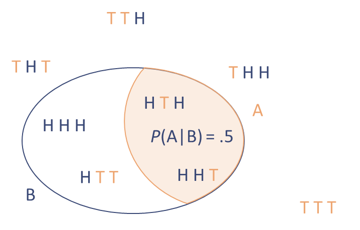

### What is all this good for?!

#### Conditional probability in action

- Suppose Tom Riddle goes to get his free WHS-covered routine magica health check-up and the test for Haripotricidal Voldemortitis (HPV) comes back positive
- He is told that the test is 92% *sensitive* (if he has HPV the test will detect it 92% of the time)
- He finds a paper that reports that the *specificity* of the test is 98.3% (if he *doesn’t* have HPV, the test will still come back positive 1.7% of the time)
- How certain should Tom be that he is riddled?
- Let’s geek out about it!
- The prevalence of HPV in the Wizarding wolrd is 421 per 100k but it’s much higher in house Slytherin at 1,516 per 100k

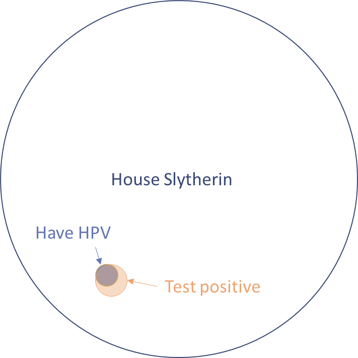

- Let’s put some numbers on it: from our data, we can create a contingency table of HPV infection and test results

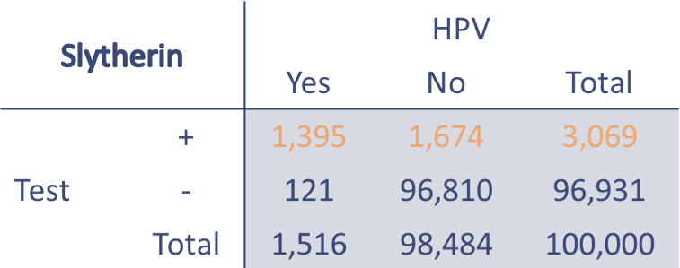

$P(HPV|pos) = \frac{P(pos|HPV) \times P(HPV)}{P(pos)}$ $P(HPV|pos) = \frac{sensitivity \times prevalence}{P(pos)}$ $P(HPV|pos) \approx \frac{.92 \times .015}{.031}$

#### That’s what all this is good for!

### Independence

- In probability theory, two events are said to be *independent* if the occurrence of one does not influence the probability of the other
- We saw that $P(HPV) \approx .015$ but $P(HPV|pos) \approx .46$
- Likewise, $P(pos) \approx .031$ but $P(pos|HPV) = .92$
- That means that having HPV and testing positive for it are dependent events
- Example of independent events would be getting H on first flip and getting T on second

### Take-home message

- Probability builds on logic
- Logic behind probability calculations
- What we mean when we say events are (in)dependent
- How conditional probability expresses the influence one event has on another

## Sampling

### Why sample?

- We want to say something about the world
- We want to empirically assess that which we’re commenting on
- Unfortunately, we don’t have access to every single instance of that thing
- So we look at *some instances*, take measurements, quantify relationships of interest and make *inferences* about other, unobserved instances

### Words. Beautiful words. The best words.

- **Population** – all possible observations in the sample space
- **Sample** – a subset of the population we actually collected data from
- **Parameter** – a property of interest in the population
- **Statistic** – a quantified expression of the property of interest in the sample

### Random draw

- When taking a sample from the population, we assume the process by which we sample is *random*
- Every member of the population has the same probability of getting selected
- That does **not** mean that every value has the same chance of being selected!

```r
## population - ten integers from 1 to 10
pop <- 1:10

## pick 5 of them at random
sample(pop, 5)
[1] 6 2 5 8 7

## different result each time
sample(pop, 5)
[1]  3  8  9 10  7
```

### Sampling from a finite population

- There are two kinds of sampling
  - with replacement
  - without replacement

```r
## sampling WITH replacement
sample(pop, 10, replace = T)
 [1]  5  2  5  5 10  6  9  2  4  9

## sampling WITHOUT replacement
sample(pop, 10)
 [1]  6  5  7  9  1  8  4 10  2  3
```

#### Sampling **with** replacement

- Let’s say our box of CeleBraTiONs contains 10 of each of the 8 chocolates
- Pick a chocolate at random, record which one it is, put it back, repeat
- What’s the probability of picking a Malteaser on the first draw? On the second?
- $P(malt1) = 10/80$
- $P(malt2) = 10/80$
- When sampling from a finite population with replacement, is any given draw influenced by the previous draws?

### Sampling **without** replacement

- Now pick a chocolate – it’s a Malteaser! – keep it, and pass the box on
- What’s the probability of picking a Malteaser on the first draw? On the second?
- $P(malt1) = 10/80 = .125$
- $P(malt2) = 9/79 = .114$
- When sampling from a finite population without replacement, individual draws are *not independent*!

### Sampling in practice

- When picking a sample, we *assume that the population is infinite*
- Even though we sample without replacement, the individual draws are essentially independent

## Variables

### More lingo

- When we collect a sample, it is because we want to measure certain **attributes** (*e.g.,* age)
- We collect one – or several – observations of the given attribute from each member of the sample
- **Domain** is a set of all possible values an observation of a given attribute can take (0 - [122+](https://en.wikipedia.org/wiki/Jeanne_Calment) years)
- **Variable** is set of attributes in which the observations vary across a domain
- Something that’s a variable in one sample may not be a variable in another sample (first language in a sample of monolingual native English speakers is a *constant*, not a variable)

### Types of variables

- Several important ones:
  - **Continuous** – can take *any* value within the range of its domain (*e.g.,* age)
  - **Discrete** – can take a specific set of values but not the values between these (*e.g.,* number of rooms in a hotel)
  - **Binomial** – special case of discrete variable; can only take two values, usually 0 and 1 (*e.g.,* pass/fail outcome of a test)

### Levels of measurement

- **Nominal** – categories with no relative ordering (*e.g.,* study programme )
- **Ordinal** – categories that can be meaningfully ordered (*e.g.,* lecture quality ranking)
- **Interval** – values are ordered and *equidistant*; no absolute zero point (*e.g.,* IQ)
- **Ratio** – like interval just with an absolute zero (*e.g.,* age)

### Variables in `R`

- `R` has no way of knowing what level of measurement or type of variable is inside a vector
- It can guess, but it’s *much* better if you tell it
- `logical` values (`TRUE/FALSE`) can only be binomial and nominal
- `character` values can only be nominal/ordinal and cannot be continuous
- `numeric` values can represent any level of measurement and any type of variable
- Read more [here](https://mivalek.github.io/resources/saviouR.html#its-elementary-my-dear-watson)

## Descriptive statistics

### First step

- Descriptive statistics give us tools to understand variables
- Essential for all statistical inference
- Exploring descriptives is an important prerequisite for data analysis
- Two main groups:
  - Measures of *central tendency*
  - Measures of *dispersion*

### Central tendency

- Average (central) value in the sample/population
- Three measures:
  - Mode
  - Median
  - Mean

#### Data

- let’s create some data to illustrate the concepts

```
    id age eye_col dpt degree
1 1001  23    blue psy    2:2
2 1002  25   brown cog      1
3 1003  33   brown lel      1
4 1004  26   green psy      1
5 1005  25    blue phi    2:1
6 1006  24   brown lel    2:1
```

- `id` – discrete nominal; unique participant ID
- `age` – continuous ratio; age in years
- `eye_col` – discrete nominal; eye colour
- `dpt` – discrete nominal; department
- `degree` – discrete ordinal; UG degree outcome

#### Central tendency: **Mode**

- The most frequent value in population/sample

```r
## see frequencies
ftab <- table(data$eye_col)
ftab

 blue brown green
    2     3     1


## get mode from table
names(ftab)[ftab == max(ftab)]
[1] "brown"
```

- A variable has **at least** one mode (*i.e.,* can have multiple modes)

```r
ftab <- table(data$dpt)
ftab

cog lel phi psy
  1   2   1   2



names(ftab)[ftab == max(ftab)]
[1] "lel" "psy"
```

- When each value has the same frequency, *every one of them* is the mode

```r
ftab <- table(data$id)
ftab

1001 1002 1003 1004 1005 1006
   1    1    1    1    1    1



names(ftab)[ftab == max(ftab)]
[1] "1001" "1002" "1003" "1004" "1005" "1006"
```

- Can be calculated on any variable type/measurement level*

```r
## mode of degree
ftab <- table(data$degree)
names(ftab)[ftab == max(ftab)]
[1] "1"


## mode of age
ftab <- table(data$age)
names(ftab)[ftab == max(ftab)]
[1] "25"
```

#### Central tendency: **Median**

- A special case of *quantile*
- If you sort your data from the smallest value to the largest and divide into *n* equal parts, the quantile is the largest value in each of the parts
- If *n = 4*, the individual cut-off points are **quartiles**
- If *n = 10*, they are **deciles**
- If *n = 100*, they are **centiles** (AKA percentiles)
- **Median** is the midpoint, *i.e.,* the only quantile if *n = 2*
- Since we’re ordering, data must be at least *ordinal*
- To find the median, first sort data

```r
(age_sort <- sort(data$age))
[1] 23 24 25 25 26 33
```

- Then, find the midpoint
  - Odd number of values: $\frac{N + 1}{2}$
  - Even number of values: $\frac{N/2 + (N / 2 + 1)}{2}$

```r
## N/2
(m1 <- age_sort[6 / 2])
[1] 25
## (N / 2) + 1
(m2 <- age_sort[length(age_sort) / 2 + 1])
[1] 25
(m1 + m2) / 2
[1] 25
```

- `R` has a handy function so we don’t have to calculate everything “by hand”

```r
(median(data$age))
[1] 25
## ordinal data must be converted to numeric for median()
(x <- ordered(sample(1:4, 10, replace = T)))
 [1] 3 3 1 2 1 3 1 2 4 2
Levels: 1 < 2 < 3 < 4
(median(as.numeric(x)))
[1] 2
## of limited use with ordered categories
(median(as.numeric(data$degree)))
[1] 1.5
## not meaningful for nominal data but can be done
(median(as.numeric(data$eye_col)))
[1] 2
```

#### Central tendency: (Arithmetic)* **Mean**

- What most people mean by *average*
  - population mean $\mu$
  - sample mean $\bar{x} = \frac{\sum_{i=1}^N x_i}{N}$
- If there are *N* observations of variable *x* in our sample, $\sum_{i=1}^N x_i = x_1+x_2+x_3+\cdots +x_N$
- Requires at least interval-level data

* Other means are available ([geometric](https://en.wikipedia.org/wiki/Geometric_mean), [harmonic](https://en.wikipedia.org/wiki/Harmonic_mean))

#### Central tendency: (Arithmetic) **Mean**

```r
data$age
[1] 23 25 33 26 25 24
sum(data$age)
[1] 156
## sum / N
sum(data$age)/nrow(data)
[1] 26
## readymade R function
mean(data$age)
[1] 26
```

- Pros
  - Algebraically tractable (has a formula)
  - Related to measures of dispersion (coming up next)
- Cons
  - Assumes data are at least interval
  - Might not actually exist in sample
  - Sensitive to extreme values (unlike mode and median)

#### Sensitive to extremes

```r
## copy age into new object
age <- data$age
## replace highest value (33) with 83
age[age == max(age)] <- 83
age
[1] 23 25 83 26 25 24
## original age
mean(data$age)
[1] 26
## new age
mean(age) # also, doesn't exist in sample!
[1] 34.33333
median(data$age) # median isn't affected
[1] 25
median(age)
[1] 25
```

### Dispersion

- Mode, median, and mean tell us about the central point in our data
- They don’t tell us how spread the data are around this point
- That is what measures of dispersion (spread) do
  - Range
  - Inter-quartile range
  - Deviation
  - Variance
  - Standard deviation

#### Dispersion: **Range**

- Distance between smallest and largest value in sample
- *Drawback:* Extremely sensitive to outliers

```r
## range() gives minimum and maximum
range(data$age)
[1] 23 33
## get the distance
max(data$age) - min(data$age)
[1] 10
```

#### Dispersion: **IQR**

- Inter-quartile range - distance between 1<sup>st</sup> and 3<sup>rd</sup> quartile
- *Drawback:* Ignores half of the data

```r
## get quartiles (quantiles with n = 4)
## cut data into lower 25%, 50%, 75%, 100%
(quartiles <- quantile(age, c(.25, .5, .75, 1)))
  25%   50%   75%  100%
24.25 25.00 25.75 83.00
## IQR = 3rd - 1st quaritle
## don't worry about the "75%", it's just a leftover label
quartiles[3] - quartiles[1]
75%
1.5
## built-in R function
IQR(data$age)
[1] 1.5
```

- Other quantiles can be used for different inter-*quantile* ranges

#### Dispersion: **Deviation**

- Distance from every single value in the data from some convenient point
- Mean is a convenient point
- $x_i - \bar{x}$, where $x_i$ is every single data point

```r
## minus is a vectorised operation in R
data$age - mean(data$age)
[1] -3 -1  7  0 -1 -2
```

- There are as many deviations as data points
- To get a single measure of spread, how about we add them all up?
- *Problem:* More data points = more points to add up
- *BIG problem:* They always add up to zero

#### Dispersion: **Variance**

- How do we get around the *BIG problem* (deviations adding up to 0)?
- By taking the square of the deviations
- The sum of these is called the **S**um of **S**quares
- We can get around the *problem* by dividing the sum of squares by *N*
- This is the **variance**
- population variance $\sigma^2 = \frac{\sum_{i=1}^N (x_i - \mu)^2}{N}$
- sample variance, $s^2 = \frac{\sum_{i=1}^N (x_i - \bar{x})^2}{N - 1}$
  - reason for the $N - 1$ is quite technical (see [Bessel’s correction](https://en.wikipedia.org/wiki/Bessel%27s_correction))

```r
## deviations
(dev <- data$age - mean(data$age))
[1] -3 -1  7  0 -1 -2
## sums of squares
(ss <- sum(dev^2))
[1] 64
## variance
ss / (length(data$age) - 1)
[1] 12.8
## in-built function
var(data$age)
[1] 12.8
```

#### Dispersion: **Standard deviation**

- Variance is a good measure of dispersion and is widely used
- One minor inconvenience – measured in *squared units*
  - if age is measured in years, $s^2_{age}$ is expressed in years<sup>2</sup>, whatever those are
- Taking the square root of variance gives us a measure of spread in the original units
- This is the standard deviation
  - $\sigma$ for population
  - $s$ (or $SD$) for sample

$$s = \sqrt{s^2} = \sqrt{\frac{\sum_{i=1}^N (x_i - \bar{x})^2}{N - 1}}$$

```r
sqrt(var(data$age))
[1] 3.577709
sd(data$age)
[1] 3.577709
```

- If we measured age in decades, $s_{ageD}$ would be **proportional** to $s_{age}$

```r
(ageD <- data$age / 10)
[1] 2.3 2.5 3.3 2.6 2.5 2.4
sd(ageD)
[1] 0.3577709
```

## Take-home message

- Relationship between *population* and *sample*
- What **random** sampling *with* and *without* replacement is
- Difference between *types* of variables and *levels of measurement*
- Central tendency describes the *average* value
- Dispersion describes how much the values are *spread*
- There are several measures, each with pros and cons
- *variance* and *standard deviation* relate to *mean*
- *SD* in cm = 100 × *SD* in m

#### See you in the labs :)